# OECD Life Expectancy and Infant Mortality

Christopher Prener, Ph.D.

(August 17, 2019)

## Introduction

This notebook creates the plots for Lecture-01 - Course Introduction for my sections of SOC 1120.

## Packages

This notebook requires the following packages:

```r
# tidyverse packages
library(dplyr)          # data wrangling
library(ggplot2)        # create plots
library(readr)          # tabular files

# plotting packages
library(RColorBrewer)   # color schemes
library(prener)         # export tools

# other packages
library(countrycode)
library(here)
```

## Load Data

All of the raw data for these slides were obtained from the OECD’s open data website:

- [GDP Per Capita, 2018](https://data.oecd.org/gdp/gross-domestic-product-gdp.htm)
- [Total Health Expenditure by Country, 2018](https://data.oecd.org/healthres/health-spending.htm)
- [Life Expectancy at Birth, 2018](https://data.oecd.org/healthstat/life-expectancy-at-birth.htm)
- [Infant Mortality, 2018](https://data.oecd.org/healthstat/infant-mortality-rates.htm)

They are in separate `.csv` files that we’ll load individually:

```r
spending <- read_csv(here("data", "DP_LIVE_11082019203859613.csv"))
lifexp <- read_csv(here("data", "DP_LIVE_11082019205910721.csv"))
infant <- read_csv(here("data", "DP_LIVE_11082019205945830.csv"))
gdp <- read_csv(here("data", "DP_LIVE_11082019213358891.csv"))
```

## Clean Data

First, we’ll clean the health care spending data by obtaining total spending and retaining only the value for the latest year available:

```r
spending <- spending %>%
  filter(SUBJECT == "TOT") %>%
  filter(TIME == 2017 | TIME == 2018) %>%
  select(LOCATION, TIME, Value) %>%
  group_by(LOCATION) %>%
  summarise(spend = last(Value), spend_year = last(TIME))
```

Similarly, we’ll take the GDP value for the latest year available:

```r
gdp <- gdp %>%
  filter(TIME == 2017 | TIME == 2018) %>%
  select(LOCATION, TIME, Value) %>%
  group_by(LOCATION) %>%
  summarise(gdp = last(Value), gdp_year = last(TIME)) %>%
  filter(LOCATION != "OECD")
```

For infant mortality, some countries do not have data for 2017 or 2018 so we need to go back further to get the latest year available:

```r
infant <- infant %>%
  filter(TIME == 2015 | TIME == 2016 | TIME == 2017 | TIME == 2018) %>%
  select(LOCATION, TIME, Value) %>%
  group_by(LOCATION) %>%
  summarise(infant = last(Value), infant_year = last(TIME))
```

Finally, we’ll get the latest available data for life expectancy at birth. We only want total life expectancy, which pools men and women together. As with the other tables, we’ll keep it only for the latest year available:

```r
lifexp <- lifexp %>%
  filter(SUBJECT == "TOT") %>%
  filter(TIME == 2016 | TIME == 2017 | TIME == 2018) %>%
  select(LOCATION, TIME, Value) %>%
  group_by(LOCATION) %>%
  summarise(lifexp = last(Value), lifexp_year = last(TIME))
```

## Combine Tables

Next, we’ll combine all four of our raw data tables into a single object:

```r
oecd <- left_join(gdp, spending, by = "LOCATION") %>%
  left_join(., lifexp, by = "LOCATION") %>%
  left_join(., infant, by = "LOCATION") %>%
  rename(loc = LOCATION)

# clean-up environment
rm(gdp, spending, lifexp, infant)
```

Finally, we’ll add full country names:

```r
oecd <- oecd %>%
  mutate(name = countrycode(loc, origin = "iso3c", destination = "country.name")) %>%
  select(loc, name, everything())
```

### GDP and Health Expenditure

First, we’ll compare GDP and health care spending:

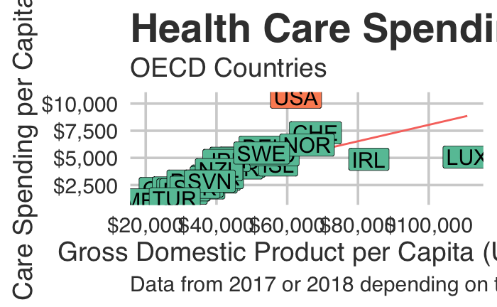

```r
# create plot
plot <- ggplot(oecd, aes(x = gdp, y = spend, label = loc)) +
          geom_smooth(aes(color = "lm"), method = "lm", se = FALSE) +
          geom_point() +
          geom_label(aes(fill = loc == "USA"), size = 8) +
          scale_y_continuous(labels = scales::dollar) +
          scale_x_continuous(breaks = scales::pretty_breaks(n=5), labels = scales::dollar) +
          labs(
            title = "Health Care Spending and GDP",
            subtitle = "OECD Countries",
            caption = "Data from 2017 or 2018 depending on the country; data via OECD",
            x = "Gross Domestic Product per Capita (USD)",
            y = "Health Care Spending per Capita (USD)"
          ) +
          scale_fill_brewer(palette = "Set2") +
          cp_sequoiaTheme(background = "transparent") +
          theme(legend.position = "none")

# save plot
cp_plotSave(here("results", "gdp_spend.png"), plot, preset = "lg")

# print plot
plot
```

### Health Care Spending and Life Expectancy

Next, we’ll compare health care spending to life expectancy at birth:

```r
# create plot
plot <- ggplot(oecd, aes(x = lifexp, y = spend, label = loc)) +
              geom_smooth(aes(color = "lm"), method = "lm", se = FALSE) +
              geom_point() +
              geom_label(aes(fill = loc == "USA"), size = 8) +
              scale_y_continuous(labels = scales::dollar) +
              scale_x_continuous(breaks = scales::pretty_breaks(n=8)) +
              labs(
                title = "Health Care Spending and Life Expectancy",
                subtitle = "OECD Countries",
                caption = "Data from 2016-2018 depending on the country; data via OECD",
                x = "Life Expectancy at Birth (years)",
                y = "Health Care Spending per Capita (USD)"
              ) +
              scale_fill_brewer(palette = "Set2") +
              cp_sequoiaTheme(background = "transparent") +
              theme(legend.position = "")

# save plot
cp_plotSave(here("results", "spend_life.png"), plot, preset = "lg")
```

### Health Care Spending and Infant Mortality

Next, we’ll compare health care spending to infant mortality rates:

```r
# create plot
plot <- ggplot(oecd, aes(x = infant, y = spend, label = loc)) +
              geom_smooth(aes(color = "lm"), method = "lm", se = FALSE) +
              geom_point() +
              geom_label(aes(fill = loc == "USA"), size = 8) +
              scale_y_continuous(labels = scales::dollar) +
              scale_x_continuous(breaks = scales::pretty_breaks(n=5)) +
              labs(
                title = "Health Care Spending and Infant Mortality",
                subtitle = "OECD Countries",
                caption = "Data from 2015-2018 depending on the country; data via OECD",
                x = "Deaths per 1,000 Live Births",
                y = "Health Care Spending per Capita (USD)"
              ) +
              scale_fill_brewer(palette = "Set2") +
              cp_sequoiaTheme(background = "transparent") +
              theme(legend.position = "")

# save plot
cp_plotSave(here("results", "spend_infant.png"), plot, preset = "lg")
```

### Infant Mortality

Finally, we’ll generate a bar plot of countries based on their infant mortality rates:

```r
# create plot
plot <- ggplot(oecd, aes(x = reorder(name, infant), y = infant)) +
              geom_bar(stat='identity', aes(fill = loc == "USA")) +
              coord_flip() +
              labs(
                title = "Infant Mortality",
                subtitle = "OECD Countries",
                caption = "Data from 2015-2018 depending on the country; data via OECD",
                x = "",
                y = "Deaths per 1,000 Live Births"
              ) +
              scale_fill_brewer(palette = "Set2") +
              cp_sequoiaTheme(background = "transparent") +
              theme(
                legend.position = "",
                axis.text.y = element_text(size = 18)
              )

# save plot
cp_plotSave(here("results", "infant_bar.png"), plot, preset = "lg")
```